# Jacobian Linearization Example

In this example, we will investigate how accurate a simulation using jacobian linearization is compared to the true nonlinear system dynamics. The system in this scenario is a water mixing tank. There is a hot water source and a cold water source and the goal is to acheive water of a specific temperature. The following nonlinear equations govern the system:

\begin{equation} \begin{split} \dot{h}(t) &= \frac{1}{A_T}(q_C(t) + q_H(t) - C_DA_o\sqrt{2gh(t})) \\ \dot{T}_T(t) &= \frac{1}{h(t)A_T}(q_C(t)[T_C - T_T(t)] + q_H(t)[T_H - T_T(t)]) \\ \end{split} \end{equation}

$h(t)$ is the height of the tank, $q_C$ is the flow rate of the cold water, $q_H$ is the flow rate of the hot water, These flow rates are our controls. $A_T$, $C_D$, $g$, and $A_o$ are just some constants.

Let's define some constraints for our simulation.

\begin{equation} \begin{split} h(0) &= 1.10 \\ T_T(0) &= 81.5 \\ q_C(0) &= \begin{cases} 0.022 & 0 \leq t \leq 25 \\ 0.043 & 25 \leq t \leq 100 \\ \end{cases} \\ q_H(0) &= \begin{cases} 0.14 & 0 \leq t \leq 60 \\ 0.105 & 60 \leq t \leq 100 \\ \end{cases} \\ \end{split} \end{equation}

We picked these numbers because they're reasonably close to the equilibrium condition of $h=1, T_T=75$. Of course the control inputs are totally arbitrary, we just want to see the impact they have on height and water temperature.

For the true system dynamics, the simulation is simple. Given the starting variable, calculate $h(0)$ and $T_T(0)$. Then, use these new outputs as the inputs at the next time step.

```python
import numpy as np
import matplotlib.pyplot as plt
import matplotlib as mpl
mpl.rcParams['axes.formatter.useoffset'] = False
mpl.rcParams['figure.figsize'] = (10,10)
```

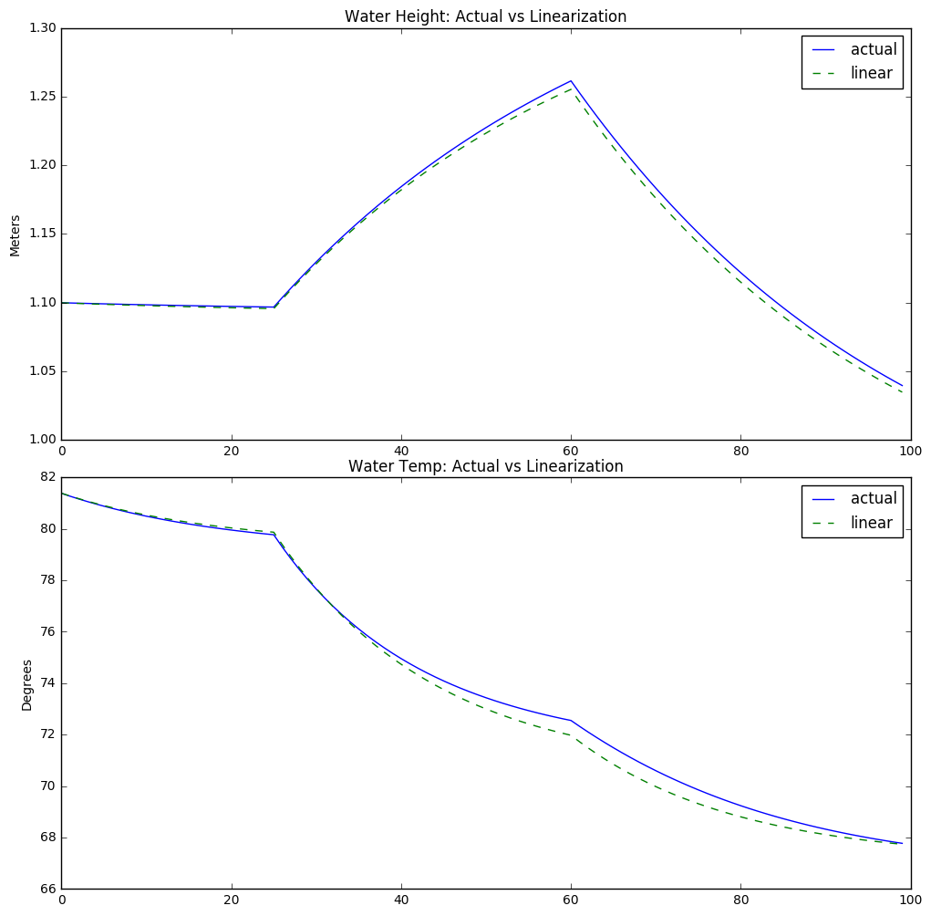

```python
def nonlinear_simulate(q_C, q_H, h0, T0, T_C=10, T_H=90, A_o=0.05, A_T=3, C_D=0.7, g=9.8, debug=False):
    h_t = h0
    T_T_t = T0
    H = []
    T = []
    for t in range(100):
        q_C_t = q_C(t)
        q_H_t = q_H(t)
        if debug:
            print(h_t, T_T_t, q_C_t, q_H_t)
        T_T_t += (q_C_t * (T_C - T_T_t) + q_H_t * (T_H - T_T_t)) / (h_t * A_T)
        h_t += (q_C_t + q_H_t - C_D * A_o * np.sqrt(2 * g * h_t)) / A_T
        H.append(h_t)
        T.append(T_T_t)

    return H, T

def linear_simulate(q_C, q_H, h0, T0, h_e=1, T_e=75, T_C=10, T_H=90, A_o=0.05, A_T=3, C_D=0.7, g=9.8, debug=False):
    # first we calculate our control inputs for the input equilibrium point (h_e, T_e)
    q_C_e = (C_D*A_o*np.sqrt(2*g*h_e)*(T_H-T_e))/(T_H-T_C)
    q_H_e = (C_D*A_o*np.sqrt(2*g*h_e)*(T_e-T_C))/(T_H-T_C)
    if debug:
        print(q_C_e, q_H_e)

    # then we solve for A and B, the coefficients of our linear system
    A = np.array([[-g*C_D*A_o/(A_T*np.sqrt(2*g*h_e)), 0],[-(q_C_e*(T_C-T_e) + q_H_e*(T_H-T_e))/(h_e*h_e*A_T), -(q_C_e+q_H_e)/(h_e*A_T)]])
    B = np.array([[1/A_T,1/A_T],[(T_C-T_e)/(h_e*A_T), (T_H-T_e)/(h_e*A_T)]])
    if debug:
        print(A)
        print(B)

    # compute initial distance between current state and equilibrium state, our delta_x
    delta_h_t = h0 - h_e
    delta_T_t = T0 - T_e

    h_t = h0
    T_T_t = T0
    H = []
    T = []
    for t in range(100):
        q_C_t = q_C(t)
        q_H_t = q_H(t)

        # compute distance between our current control and equilibrium control, our delta_u
        delta_q_C = q_C_t - q_C_e
        delta_q_H = q_H_t - q_H_e

        # use the linear form to update our delta values
        delta_x = np.array([delta_h_t, delta_T_t])
        delta_u = np.array([delta_q_C, delta_q_H])
        delta_x += A@delta_x + B@delta_u

        delta_h_t = delta_x[0]
        delta_T_t = delta_x[1]

        h_t = h_e + delta_h_t
        T_T_t = T_e + delta_T_t

        H.append(h_t)
        T.append(T_T_t)

    return H, T

def q_C(t):
    if t <= 25:
        return 0.022
    else:
        return 0.043

def q_H(t):
    if t <= 60:
        return 0.14
    else:
        return 0.105

def q_C_eq(t):
    return 0.029

def q_H_eq(t):
    return 0.126

def make_plots(q_C, q_H, h0, T0):
    actual_H, actual_T = nonlinear_simulate(q_C, q_H, h0, T0)
    linear_H, linear_T = linear_simulate(q_C, q_H, h0, T0)

    fig, ax = plt.subplots(nrows=2, ncols=1)
    fig.tight_layout()
    ax[0].plot(actual_H, label="actual")
    ax[0].plot(linear_H, label="linear", linestyle='dashed')
    ax[0].set_title("Water Height: Actual vs Linearization")
    ax[0].set_ylabel("Meters")
    ax[0].legend()

    ax[1].plot(actual_T, label="actual")
    ax[1].plot(linear_T, label="linear", linestyle='dashed')
    ax[1].set_title("Water Temp: Actual vs Linearization")
    ax[1].set_ylabel("Degrees")
    ax[1].legend()

    plt.show()

make_plots(q_C, q_H, 1.1, 81.5)
```

## HELL YEA, It works!

We just ran a simulation comparison between a linearization of a nonlinear system and the original nonlinear system. Go math! Let's try some other scenarios...

### Higher water, lower temp

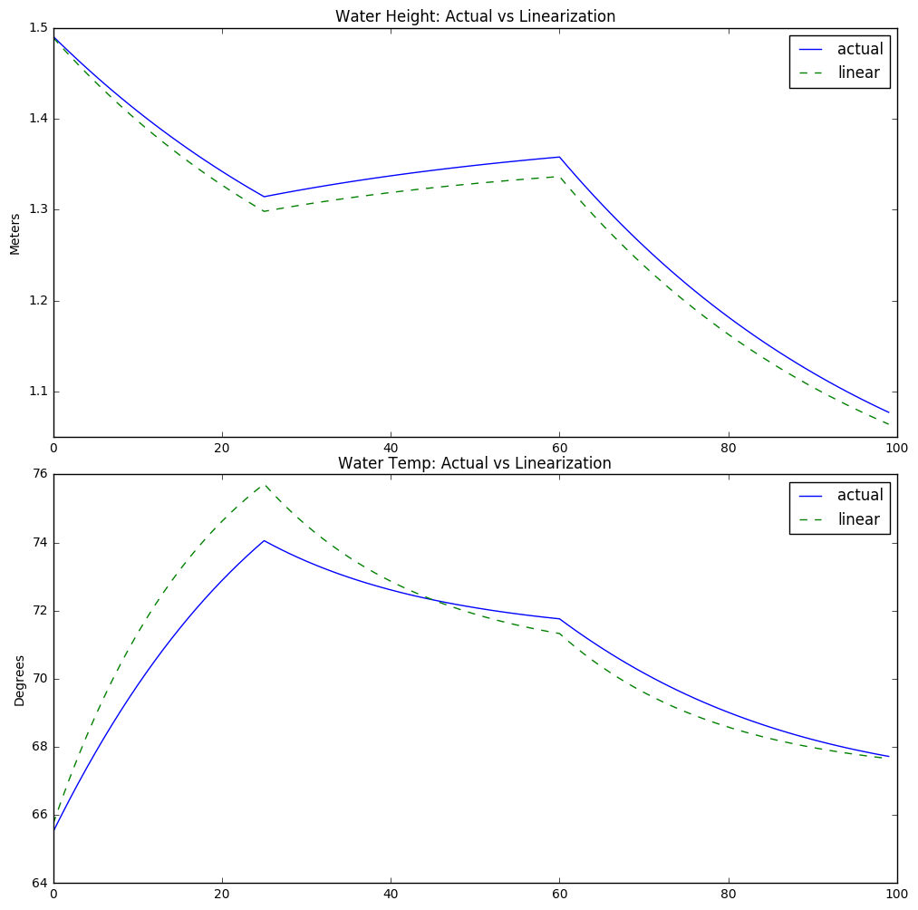

```python
make_plots(q_C, q_H, 1.5, 65)
```

### Lower Water, Higher Temp

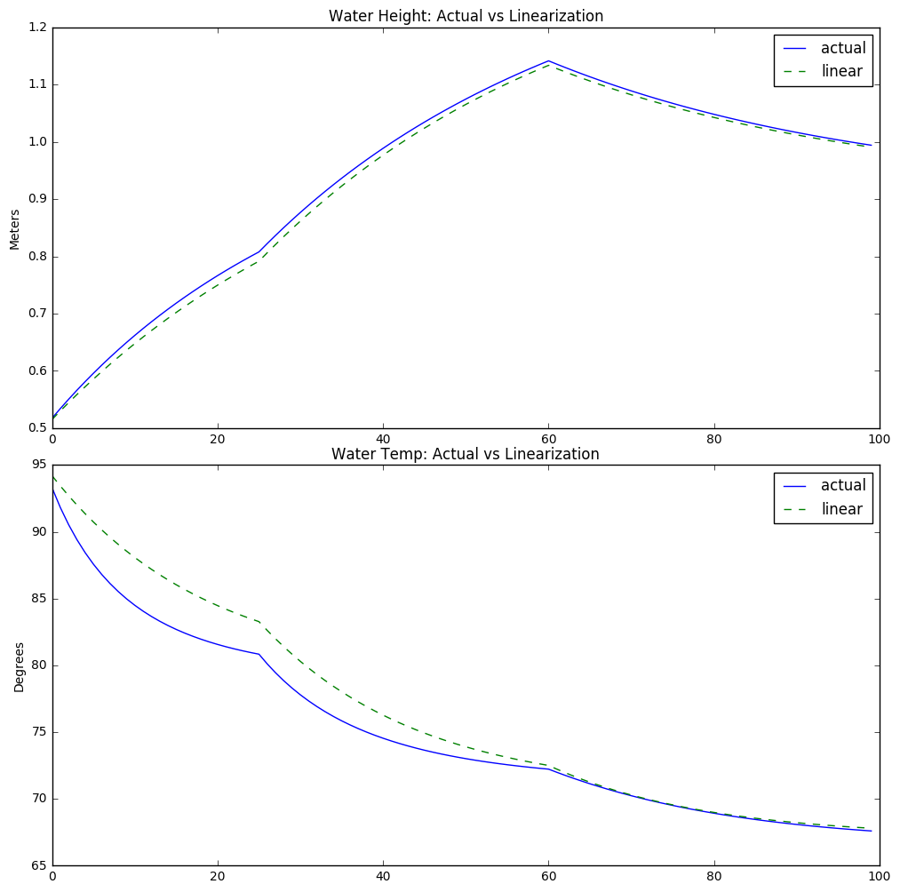

```python
make_plots(q_C, q_H, 0.5, 95)
```

### What about the equilibrium point itself? (and use the correct control for that point)

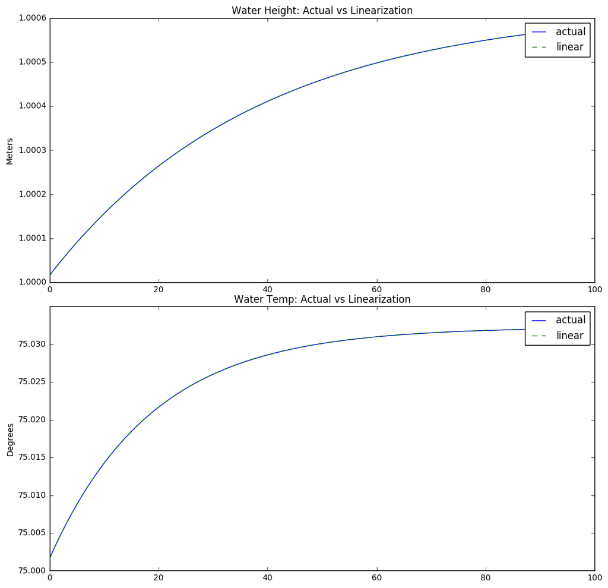

```python
make_plots(q_C_eq, q_H_eq, 1.0, 75.0)
```

### Unsurprisingly, it matches perfectly! (and barely changes, look at the axis scale)